# Class Project: Practical Machine Learning

### Synopsis

Using wearable devices such as Jawbone Up, Nike FuelBand, and Fitbit it is now possible to collect a large amount of data about personal activity relatively inexpensively. This data is being used to transform how individuals approach health. In this project, data collected from wearable devices will be used to assess how well a participant is performing bar bell lifts. The data is collected from six participants who are wearing accelerometers on the belt, forearm, and dumbell. The goal of the project is to determine how well the bar bell lifts are being performed which is classified into one of the following: Class A: Lifts were performed exactly according to specification Class B: Lifts were performed by throwing the elbows to the front Class C: Lifts were performed by only lifting the dumbell halfway Class D: Lifts were performed by lowering the dumbell only halfway Class E: Lifts were performed by throwing the hips to the front

### Executive Summary & Conclusions

In this project, personal activity data is used to evaluate how well an activity was performed. Six participants were asked to perform barbell lifts correcty and incorrectly while measurements were taken from accelerometers on the belt and forearms and bar bells. In all there were 19,622 observations and 160 features. From this data two prediction models are created and evaluated. The algorithms used for the prediction models included decision tree and random forest. Predictions generated from the Random Forest model were more accurate than predictions generated from the decision tree model. As a result, the random forest model is used to evaluate 20 observations required for the submission portion of this project. The details and results for this project are provided in the steps below.

Caveat: The purpose of this project is limited to using data captured through wearable devices. It is not intended to replace experience, good judgement, or to suggest behavioral changes related to bar bell lifts.

### PreProcessing

The data used for this project were downloaded from HAR website (see Resources section) and stored locally. The data includes two files; one to be used for training and testing the prediction models and the other file includes the 20 observations and will be used for the valiation and submission portion of this project. In this section, both data sets will be read in. The data sets will be prepared for analysis which means some data strings will be normalized and convererted to NAs (blanks, “”, NA, #DIV/o!). The features will then be evaluated for predictive value and features that are not useful will be removed.

- Load libraries, set global options and seed
- Read in the data, convert empty or missing strings to NA, remove columns with NA values.

  ```
  Rows in train set: 19622; original #columns: 160;  current #columns: 60
  ```

- Check for columns with near zero variance and remove
- Remove columns that add little predictive value (x, user_name, date related columns)

  ```
  Final train data set: Row count: 19622; Column count: 52
  ```

- Split the data into two subsets (60/40); one to be used for training and one to be used for testing
- Profile and plot the final training data set

```
## [1] 11776    52
```

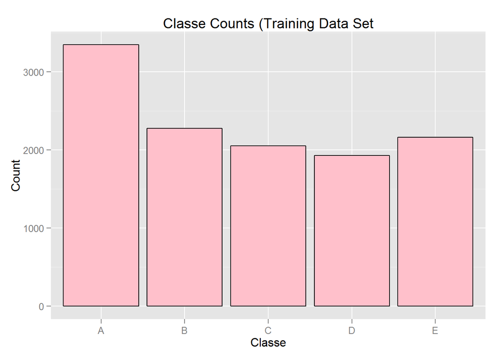

### Train and Compare Two Prediction Models

In this section two predictive models will be created; one using decision tree and one using random forest. Both models will be trained on the same data set (Training) and tested on the same data set (Testing). The decision tree will be created using the rpart function in R and the 2nd model will be created using the randomForest function in R. One model will be selected as most accurate based on output from the confusionMatrix function in R.

Out-of-sample error will be applied in the following way:  
* Expected out-of-sample error will be determined for the final (validation) data set.  
* It will be calculated as 1 - accuracy of the best performing model using testing data set.

Cross validation will be applied in the following manner:  
* If the accuracy of a baseline model is low, there is no concern for over-fitting so cross-validation will not be applied.  
* If the accuracy of the models is high, cross validation will be considered.

#### Create first prediction model: Decision Tree

- Fit the model and plot the decision tree

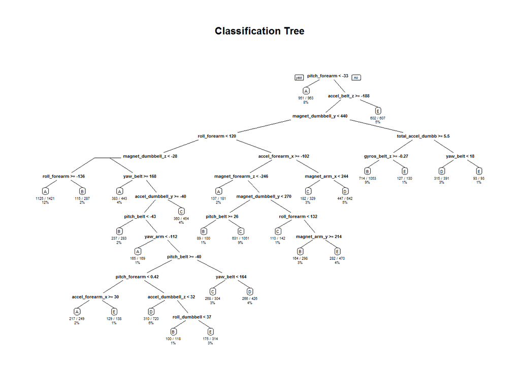

```r
fitMod1 <- rpart(classe ~., data=Training, method="class")
rpart.plot(fitMod1, main="Classification Tree", extra=102, under=TRUE, faclen=0)
```

- Generate the prediction and confusion matrix

```r
# Prediction:
predMod1 <- predict(fitMod1, Testing, type = "class")
cm1 <- confusionMatrix(predMod1, Testing$classe)
cm1$table
```

```
##           Reference
## Prediction    A    B    C    D    E
##          A 1970  241   13   36   41
##          B   73  913   98  117  223
##          C   41  146 1008  122  155
##          D  129  150  223  877   91
##          E   19   68   26  134  932
```

```r
# printcp(fitMod1)
```

#### Create second prediction model: Random Forest

- Fit the model

```r
fitMod2 <- randomForest(classe ~., data=Training, method="class")
```

- Generate the prediction and the confusion matrix

```r
# Prediction:
predMod2 <- predict(fitMod2, Testing, type = "class")
cm2 <- confusionMatrix(predMod2, Testing$classe)
cm2$table
```

```
##           Reference
## Prediction    A    B    C    D    E
##          A 2229   15    0    0    0
##          B    2 1496    9    0    0
##          C    0    7 1358   20    0
##          D    0    0    1 1264    2
##          E    1    0    0    2 1440
```

#### Compare Accuracy, Consider Cross-Validation

```r
accuracyDTTest <-  postResample(predMod1, Testing$classe)
accuracyRFTest <-  postResample(predMod2, Testing$classe)
OutOfSampleErrRFTrain <- 1 - accuracyRFTest
OutOfSampleErrRFTest <- 1 - accuracyRFTest
```

```
    Findings:
       1.  Accuracy for the Decision Tree model is low on the Testing Set: 0.7264848.
           There is no concern for over-fitting so there is no need for cross-validation.
       2.  The accuracy of the Random Forest model is very high: 0.9924802.
           However, Random Forest algorithm uses bootstrap sampling so there is no added-value value
           to apply cross-validation to protect against over-fitting.
       Therefore, cross-validation will not be applied to either model.
```

#### Final Accuracy and Out-of-sample-error

The Random Forest algorithm performed better than the Decision Tree algorithm with an accuracy of 0.9924802. For this reason the Random Forest model is selected to predict the classe outcome for each of the original 20 observations. The expected out-of-sample error for the original 20 observations is expected to be 0.0075198 which means there should be no mis-classified observations.

### Submission: Prediction on Original Test Set

- Prepare and submit Part 2 of the assignment.

```
##  1  2  3  4  5  6  7  8  9 10 11 12 13 14 15 16 17 18 19 20
##  B  A  B  A  A  E  D  B  A  A  B  C  B  A  E  E  A  B  B  B
## Levels: A B C D E
```

### References

[1] The data for this project downloaded from Human Activity Recognition website: http://groupware.les.inf.puc-rio.br/har [2] Citation for data used in this project: Velloso, E.; Bulling, A.; Gellersen, H.; Ugulino, W.; Fuks, H. Qualitative Activity Recognition of Weight Lifting Exercises. Proceedings of 4th International Conference in Cooperation with SIGCHI (Augmented Human ’13) . Stuttgart, Germany: ACM SIGCHI, 2013.